# COVID-19 hospitalizations in Emilia-Romagna, Italy

## Objective

The goal of the project is computing short-term forecasts of COVID-19 hospitalizations in the Italian region Emilia-Romagna during the period from September 2021 to March 2023.

The predictions are computed weekly ($Q=7$), starting from Wednesdays, using data from the last $W=21$ days. As covariates, we consider:

- day of the week
- if it improves the BIC, the number of positive cases (smoothed) with lag 7 or 10.

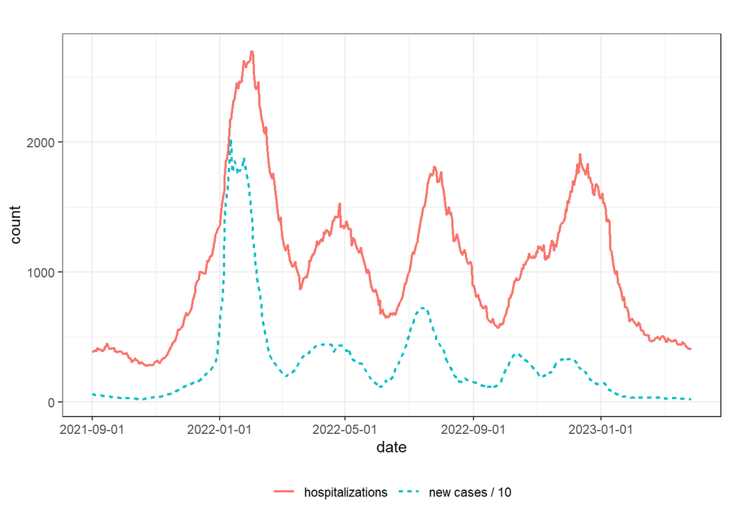

## Model

We evaluated multiple models:

- INGARCH models: stationary, linear, quadratic, and cubic
- flexible GLM with cubic splines of the time as covariate
- Generalized Additive Model (GAM) with a smooth function of time
- Bayesian Structural Time Series (BSTS) with linear and seasonal trends
- Artificial Neural Network (ANN) with 2 hidden layers and 10 repetitions

Finally, we selected the models with the best overall performance across the whole period: GAM, BSTS, ANN. These model contribute to the Ensemble, with weights that vary for each prediction window according to their performance in the previous period.

## Predictions

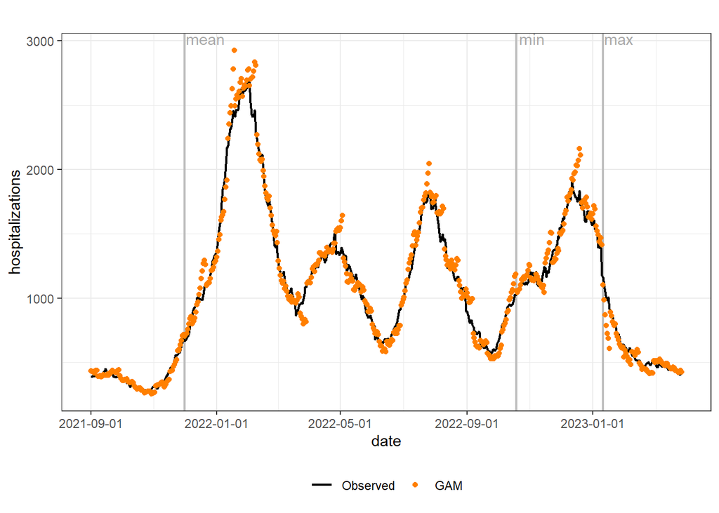

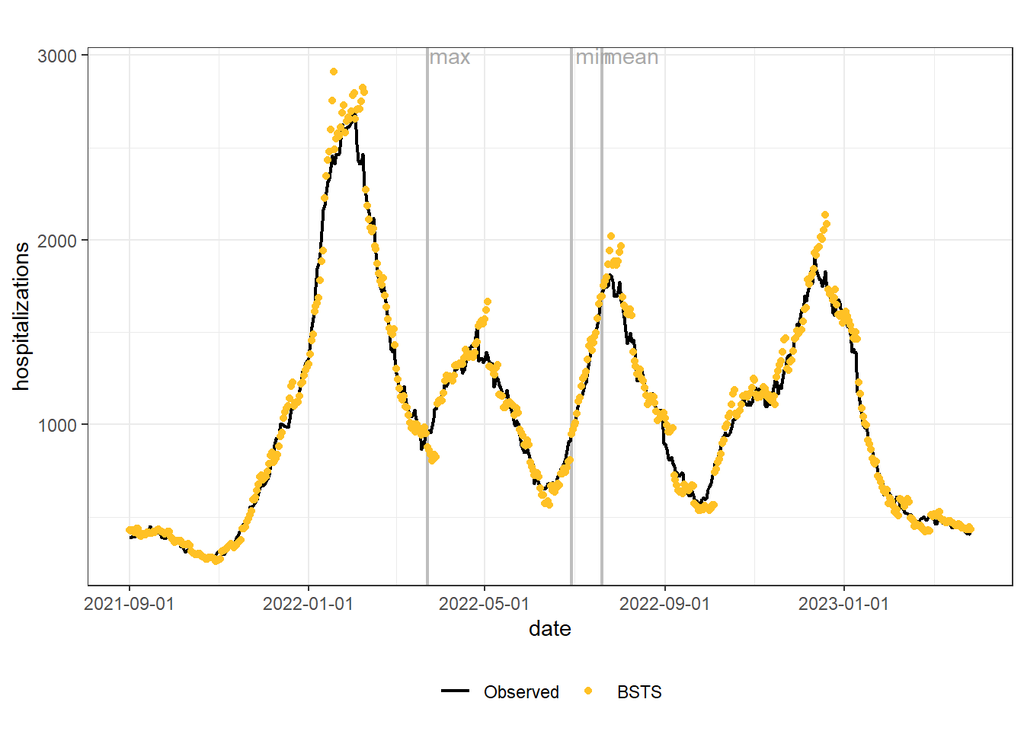

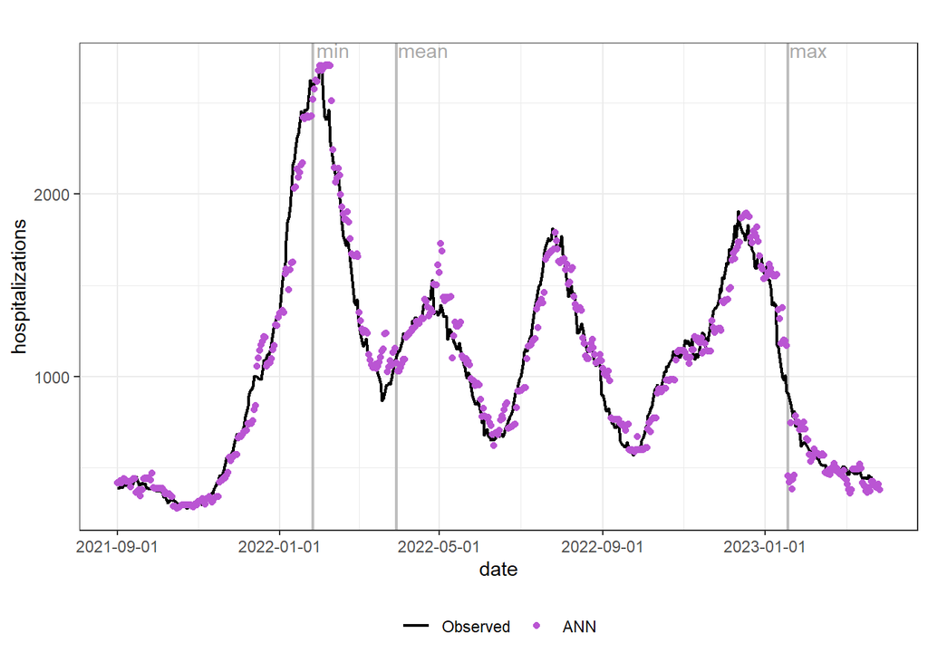

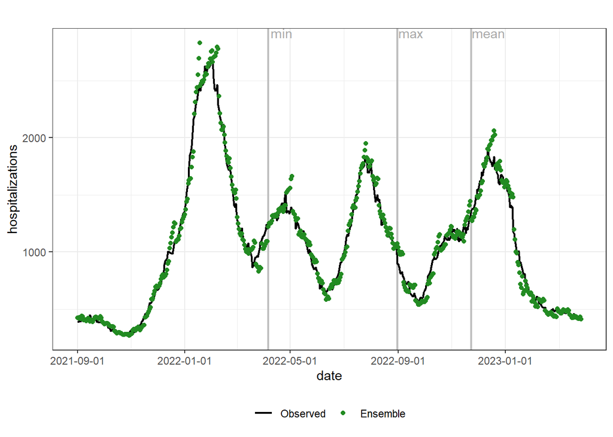

## Best, mean and worst Ensemble MSDs

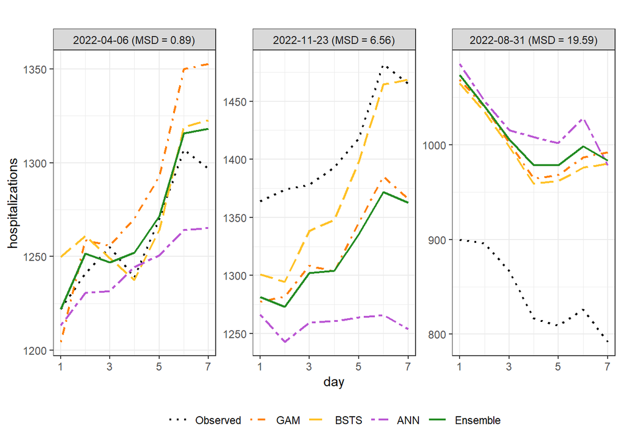

## Comparison

```
##        GAM BSTS  ANN Ensemble
## best  15.9 36.6 24.4     23.2
## 2nd   31.7 30.5  3.7     34.1
## 3rd   23.2 23.2 12.2     41.5
## worst 29.3  9.8 59.8      1.2
```

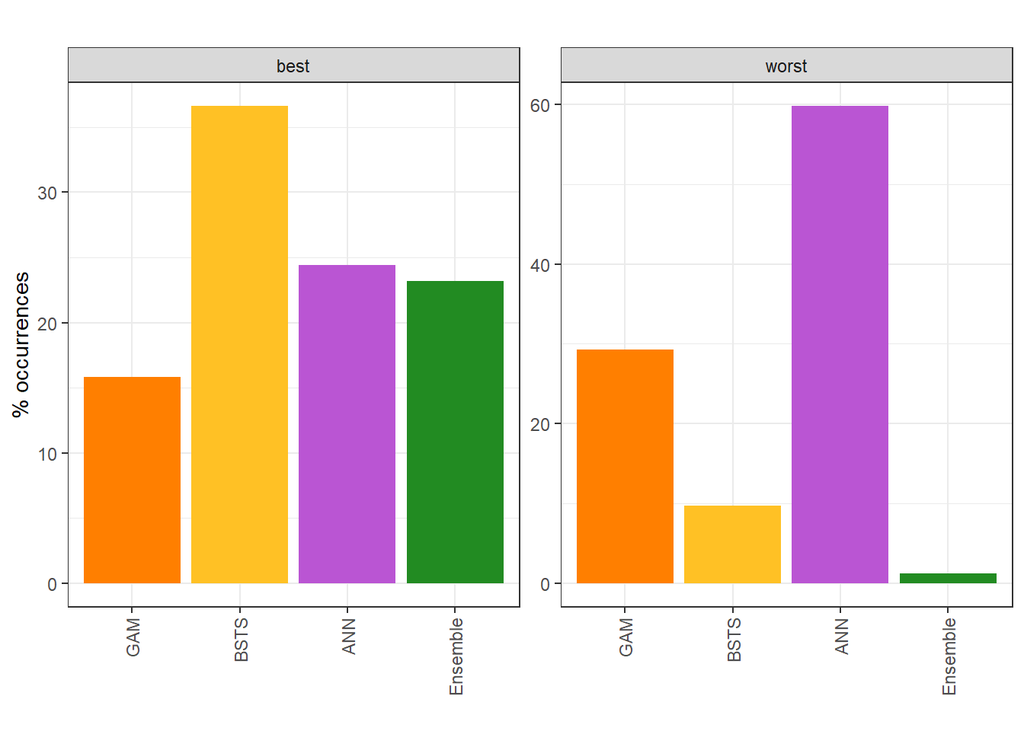

Overall MSD:

```
##      GAM     BSTS      ANN Ensemble
##     9.20     8.29    11.37     8.29
```